| R code for GV900 Homework Assignment 2 |
| --- |
| University of Essex |

### Task 1- Load 6 r packages

```r
library(ggplot2)
library(gmodels)
library(Hmisc)
library(stargazer)
library(effects)
library(gridExtra)
```

### Task 2- Load Titanic csv file and store as object called td.

```r
td.fp <- file.path("data","titanic.csv")
td. <- read.csv(td.fp)
```

### Task 3- How many passengers were on board?

```r
nrow(td.) #Answer: 1309
```

```
## [1] 1309
```

### Task 4 - Create a frequency table for the survived variable

```r
table(td.$survived)
```

```
##
##   0   1
## 809 500
```

### Task 5- Calculate the survival percentage

1309 passengers

500 survived

500/1309*100 = 38.1971%

### Task 6- Create a frequency table for class tickets

```r
table(td.$pclass)
```

```
##
##   1   2   3
## 323 277 709
```

### Task 7- Identifying Variables

**What is the dependent variable of the investigation?**

*Answer: Passenger Survival*

**What is the independent variable of the investigation?**

*Answer*: *Socio-Economic class of passengers*

### Task 8- Create a cross-tabulation table for ‘pclass’ and ‘survived’ variables

```r
CrossTable(td.$ survived, td.$ pclass, prop.r = FALSE,
prop.t = FALSE,
prop.chisq = FALSE, chisq = TRUE)
```

```
##
##
##    Cell Contents
## |-------------------------|
## |                       N |
## |           N / Col Total |
## |-------------------------|
##
##
## Total Observations in Table:  1309
##
##
##              | td.$pclass
## td.$survived |         1 |         2 |         3 | Row Total |
## -------------|-----------|-----------|-----------|-----------|
##            0 |       123 |       158 |       528 |       809 |
##              |     0.381 |     0.570 |     0.745 |           |
## -------------|-----------|-----------|-----------|-----------|
##            1 |       200 |       119 |       181 |       500 |
##              |     0.619 |     0.430 |     0.255 |           |
## -------------|-----------|-----------|-----------|-----------|
## Column Total |       323 |       277 |       709 |      1309 |
##              |     0.247 |     0.212 |     0.542 |           |
## -------------|-----------|-----------|-----------|-----------|
##
##
## Statistics for All Table Factors
##
##
## Pearson's Chi-squared test
## ------------------------------------------------------------
## Chi^2 =  127.8592     d.f. =  2     p =  1.720826e-28
##
##
##
```

### Task 9 - Interpret the cross-tabulation table

1. **What is the survival rate among 1st class passengers**

*Answer a): 61.9%*

2. **What is the survival rate among 2nd class passengers**

   *Answer b): 43.0%*
3. **What is the survival rate among 3rd class passengers**

   *Answer c): 25.5%*

### Task 10- Relationship with socio-economic class and survival

According to the statistics, there is a negative relationship between the passengers socio-economic class, and the rate of survival. It appears that the richer the passengers were, the higher likelihood that they would survive the sinking, as we predicted in our hypothesis.

### Task 11- Summarizing the results

*Answer 1): j (0.05)*

*Answer 2): n (reject)*

*Answer 3): g (95%)*

*Answer 4): p (do not find)*

### Task 12- Explore the relationship between female passengers and fare

```r
td.Fare <- td.[!is.na(td.$fare),]
```

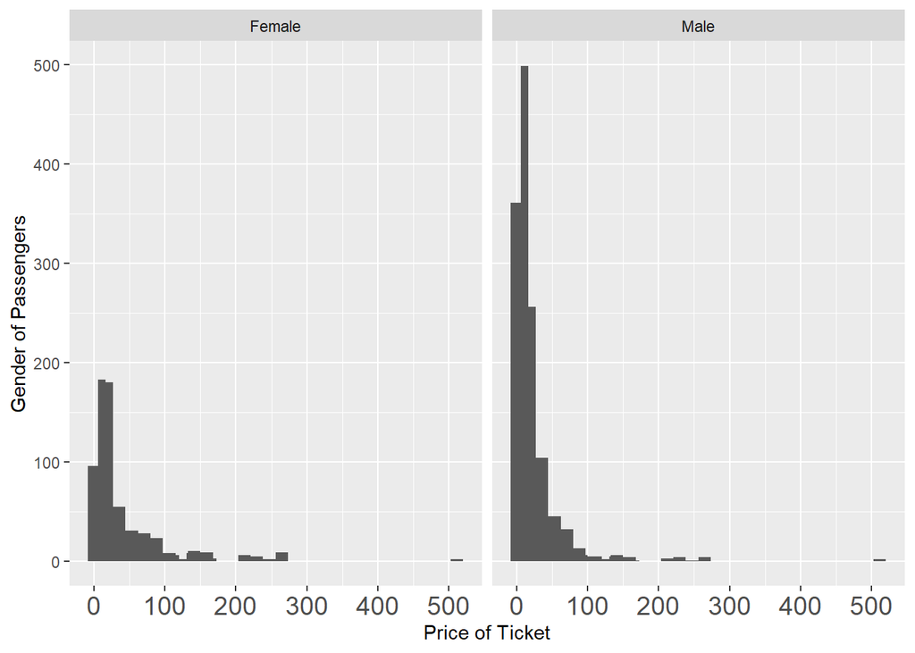

```r
g <- ggplot(td.Fare, aes(x = fare)) + geom_histogram()
g <- g + theme(axis.text.x = element_text(size = 14))
g <- g + xlab("Price of Ticket") + ylab("Gender of Passengers")
g <- g + stat_bin(bins=50)
g <- g + facet_grid(~ female)
g
```

```r
by(data = td.Fare $ fare,
   INDICES = td.Fare $ female,
   FUN = summary)
```

```
## td.Fare$female: Female
##    Min. 1st Qu.  Median    Mean 3rd Qu.    Max.
##    6.75   10.50   23.00   46.20   55.33  512.00
## ------------------------------------------------------------
## td.Fare$female: Male
##    Min. 1st Qu.  Median    Mean 3rd Qu.    Max.
##   0.000   7.876  11.887  26.154  26.550 512.000
```

```r
t.test( fare ~ female,
        data = td.Fare,
        var.equal = TRUE)
```

```
##
##  Two Sample t-test
##
## data:  fare by female
## t = 6.824, df = 1306, p-value = 1.351e-11
## alternative hypothesis: true difference in means is not equal to 0
## 95 percent confidence interval:
##  14.28092 25.80481
## sample estimates:
## mean in group Female   mean in group Male
##             46.19668             26.15382
```

### Task 13- Interpret the results of the bivariate test

Looking at the graph, it appears that females pay more for their ticket then men do, because the vast majority of the male tickets were priced under at £100 or under, whereas there is still a significant amount of females who paid over that amount.

This appears true of we look at the mean price comparison. The mean price for females was £46.20 whereas the mean price for men was £26.15.

Overall, looking at the graphs and statistics, it is evident that female passengers had more expensive tickets compared to men

### Task14- Explore the relationship between age and fare graphically

```r
# Remove rows with NULL age
td.age <- td.[!is.na(td.$age),]
```

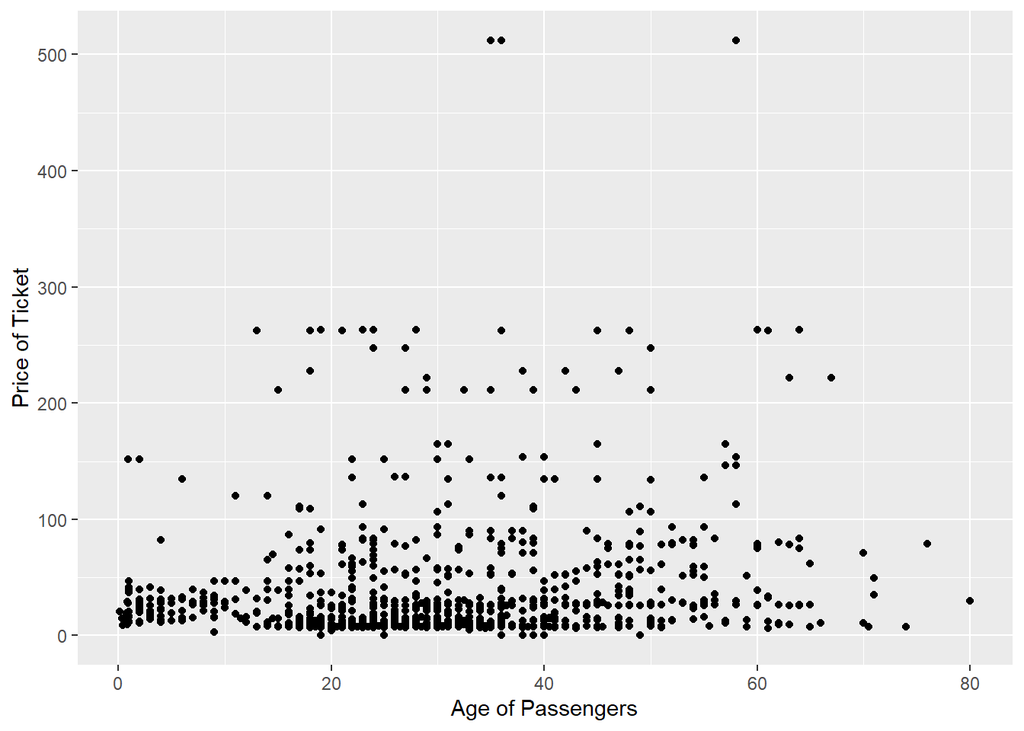

```r
g <- ggplot(td.age, aes( x=age, y=fare) ) + geom_point()
g <- g + ylab("Price of Ticket") + xlab("Age of Passengers")
g
```

### Task 15- Perform an appropriate bivariate statistical test to explore the relationship between age and fare

```r
td.ag.fr <- na.omit(td.[,c(4,11)])

lab.uni.mat <- as.matrix(td.ag.fr[ c("fare","age")])
rcorr(lab.uni.mat, type = "pearson")
```

```
##      fare  age
## fare 1.00 0.18
## age  0.18 1.00
##
## n= 1045
##
##
## P
##      fare age
## fare       0
## age   0
```

### Task 17- Regress fare on age, and produce a regression table using the stargazer function.

```r
fit.1 <- lm(fare ~ age, data = td.)

stargazer(fit.1, type = "text")
```

```
##
## ===============================================
##                         Dependent variable:
##                     ---------------------------
##                                fare
## -----------------------------------------------
## age                          0.692***
##                               (0.118)
##
## Constant                     16.021***
##                               (3.909)
##
## -----------------------------------------------
## Observations                   1,045
## R2                             0.032
## Adjusted R2                    0.031
## Residual Std. Error     54.851 (df = 1043)
## F Statistic          34.428*** (df = 1; 1043)
## ===============================================
## Note:               *p<0.1; **p<0.05; ***p<0.01
```

### Task 18- Create a plot that illustrates the estimated effect of age on fare based on the model you estimated above

```r
effect("age", mod = fit.1)
```

```
##
##  age effect
## age
##      0.2       20       40       60       80
## 16.15897 29.86510 43.70967 57.55425 71.39882
```

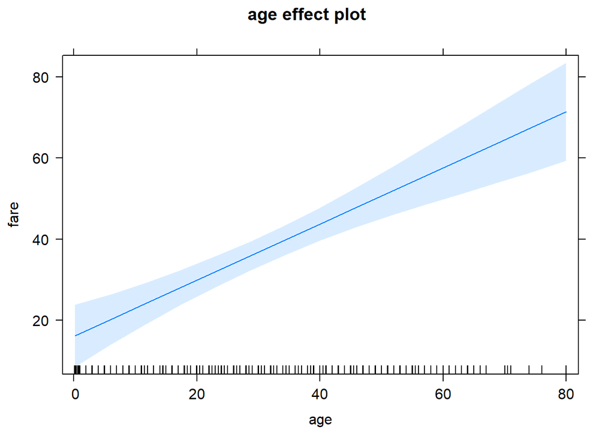

```r
eff.age <- effect("age", mod = fit.1)
plot(eff.age)
```

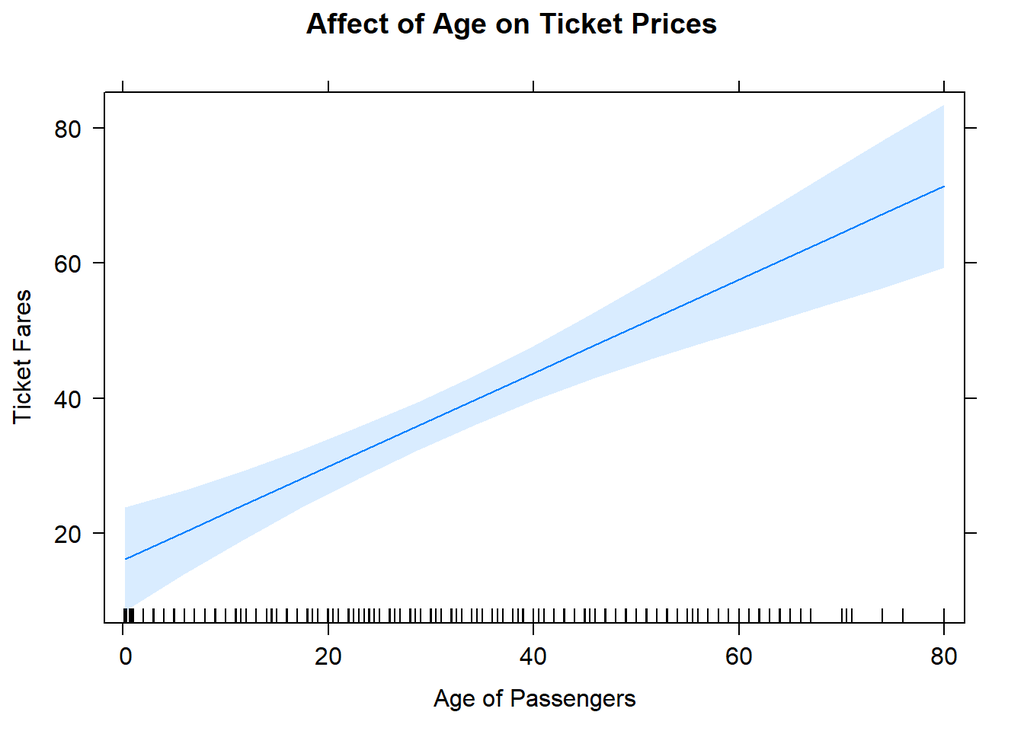

```r
plot(eff.age,
     main = "Affect of Age on Ticket Prices",
     xlab = "Age of Passengers",
     ylab = "Ticket Fares")
```

### Task 20- Graphically explore the relationship between age and fare, holding constant the female variable

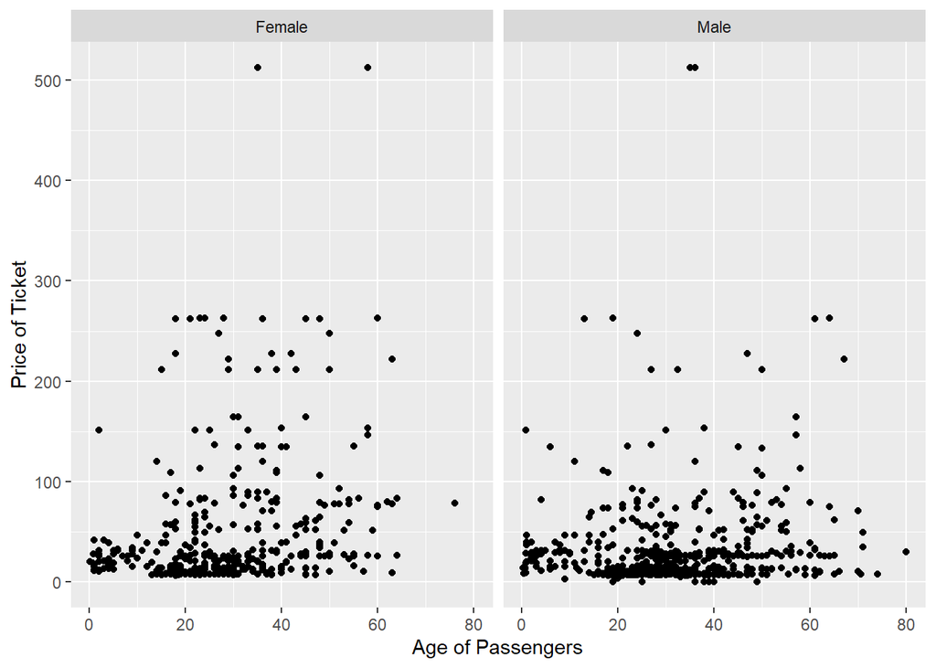

```r
td.ag.ge.fr <- na.omit(td.[,c(4,7,11)])

g <- ggplot(td.ag.ge.fr, aes( x=age, y=fare) ) + geom_point()
g <- g + ylab("Price of Ticket") + xlab("Age of Passengers")
g <- g + facet_grid(~ female)
g
```

### Task 21

### Using stargazer, regress fare on age and female

```r
# New Model fare ~ female
fit.2 <- lm(fare ~ age + female, data = td.)

# Summarise model
summary(fit.2)
```

```
##
## Call:
## lm(formula = fare ~ age + female, data = td.)
##
## Residuals:
##    Min     1Q Median     3Q    Max
## -66.12 -24.79 -13.79   3.25 480.06
##
## Coefficients:
##             Estimate Std. Error t value Pr(>|t|)
## (Intercept)  29.0673     4.2987   6.762 2.27e-11 ***
## age           0.7404     0.1158   6.393 2.44e-10 ***
## femaleMale  -23.0387     3.4473  -6.683 3.80e-11 ***
## ---
## Signif. codes:  0 '***' 0.001 '**' 0.01 '*' 0.05 '.' 0.1 ' ' 1
##
## Residual standard error: 53.74 on 1042 degrees of freedom
##   (264 observations deleted due to missingness)
## Multiple R-squared:  0.07174,    Adjusted R-squared:  0.06996
## F-statistic: 40.27 on 2 and 1042 DF,  p-value: < 2.2e-16
```

Compare the model from Task 17 (fit.1) with the model from this Task (fit.2)

```r
 suppressWarnings( # Using supressWarnings here to remove length NULL message
                  stargazer(fit.1,fit.2, type = "text")
                  )
```

```
##
## =====================================================================
##                                    Dependent variable:
##                     -------------------------------------------------
##                                           fare
##                               (1)                      (2)
## ---------------------------------------------------------------------
## age                         0.692***                 0.740***
##                             (0.118)                  (0.116)
##
## femaleMale                                          -23.039***
##                                                      (3.447)
##
## Constant                   16.021***                29.067***
##                             (3.909)                  (4.299)
##
## ---------------------------------------------------------------------
## Observations                 1,045                    1,045
## R2                           0.032                    0.072
## Adjusted R2                  0.031                    0.070
## Residual Std. Error    54.851 (df = 1043)       53.737 (df = 1042)
## F Statistic         34.428*** (df = 1; 1043) 40.267*** (df = 2; 1042)
## =====================================================================
## Note:                                     *p<0.1; **p<0.05; ***p<0.01
```

### Task 22

### Which one of the two regression models performs better?

*Answer 1): D (Adjusted R2)*

*Answer 2): F (Smaller)*

*Answer 3): H (First)*

*Answer 4): I (Second*)

### Task 23 - Estimate the effect of female on fare based on the second regression model you estimated

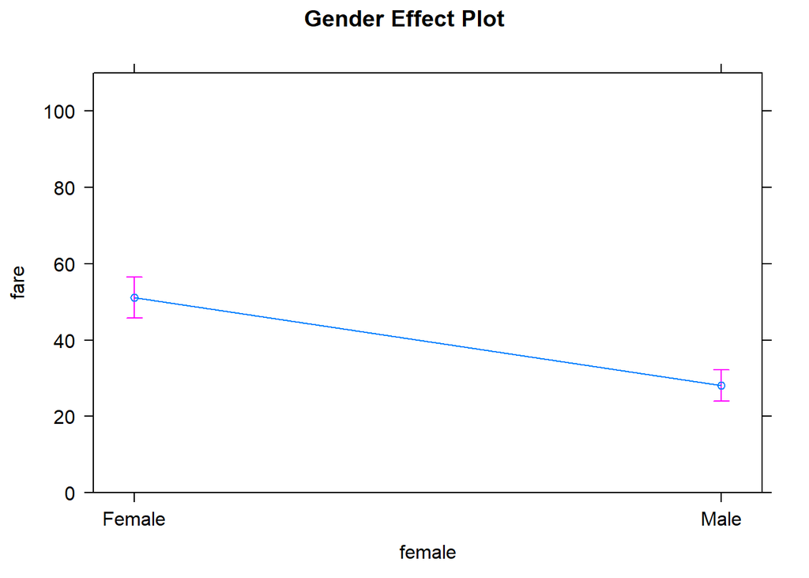

```r
eff.fr.ge <- effect(term = "female",
                      mod = fit.2)
(plot.fr.ge <- plot(eff.fr.ge,  main = "Gender Effect Plot", ylim = c(0, 110)))
```

### Task 24 - Create a plot that estimates age on fare for male and female passengers separately based on the second regression model

#### Effects and Plot solution (holding Female variable constant)

Convert female to binary variable. Run linear regression using new binary variable. Generate effect objects for Male and Female holding on female as constant.

```r
female.1 <- ifelse(td. $ female == "Female", 1, 0)
fit.3 <- lm(fare ~ age + female.1, data = td.)
eff.fr.ag.ge.1 <- effect(term = "age",
                      mod = fit.3,
                      given.values = c("female.1" = 1))
eff.fr.ag.ge.0 <- effect(term = "age",
                      mod = fit.3,
                      given.values = c("female.1" = 0))
```

Generate plot objects.

```r
plot.fr.ag.ge.1 <- plot(eff.fr.ag.ge.0,  main = "Female Effect Plot"  , ylim = c(0, 110))
plot.fr.ag.ge.0 <- plot(eff.fr.ag.ge.0,  main = "Male Effect Plot"  , ylim = c(0, 110))
```

Output plots in 2 column, side-by-side, for female and male.

[figure not shown]

```r
grid.arrange(plot.fr.ag.ge.1, plot.fr.ag.ge.0, ncol = 2)
```

**End of File**